# Composition And Proportions

# Goal

This notebook shows how to visualize composition: what a whole is made of.

Composition questions usually require proportions, not only counts.

# Analytic Questions

We will ask:

- What is the race/ethnicity composition of selected states?
- How do proportions differ from raw counts?
- When does a stacked bar help, and when does it make comparison harder?

# Load Data

```r
census_path <- "data/real/census_state_race_ethnicity_long.csv"

census <- read_csv(census_path, show_col_types = FALSE)

census |>
  glimpse()
```

```
Rows: 357
Columns: 8
$ state                           <chr> "MA", "MA", "MA", "MA", "MA", "MA", "M…
$ state_name                      <chr> "Massachusetts", "Massachusetts", "Mas…
$ rank                            <dbl> 1, 1, 1, 1, 1, 1, 1, 2, 2, 2, 2, 2, 2,…
$ total_population                <dbl> 6892503, 6892503, 6892503, 6892503, 68…
$ race_ethnicity                  <chr> "American Indian and Alaska Native", "…
$ race_ethnicity_population       <dbl> 9387, 504900, 457055, 887685, 1607, 92…
$ total_race_ethnicity_population <dbl> 6701639, 6701639, 6701639, 6701639, 67…
$ share                           <dbl> 0.0014007021, 0.0753397788, 0.06820048…
```

Each row is one race/ethnicity category within one state.

# Choose A Few States

Use a small number of states so the composition plot is readable.

```r
selected_states <- census |>
  filter(state %in% c("CA", "FL", "MD", "MA", "TX", "WA"))

selected_states |>
  select(state_name, race_ethnicity, race_ethnicity_population, share) |>
  head()
```

```
# A tibble: 6 × 4
  state_name    race_ethnicity                    race_ethnicity_popul…¹   share
  <chr>         <chr>                                              <dbl>   <dbl>
1 Massachusetts American Indian and Alaska Native                   9387 1.40e-3
2 Massachusetts Asian                                             504900 7.53e-2
3 Massachusetts Black                                             457055 6.82e-2
4 Massachusetts Hispanic or Latino                                887685 1.32e-1
5 Massachusetts Native Hawaiian and Other Pacifi…                   1607 2.40e-4
6 Massachusetts Other                                              92108 1.37e-2
# ℹ abbreviated name: ¹race_ethnicity_population
```

# Raw Counts

Start with counts.

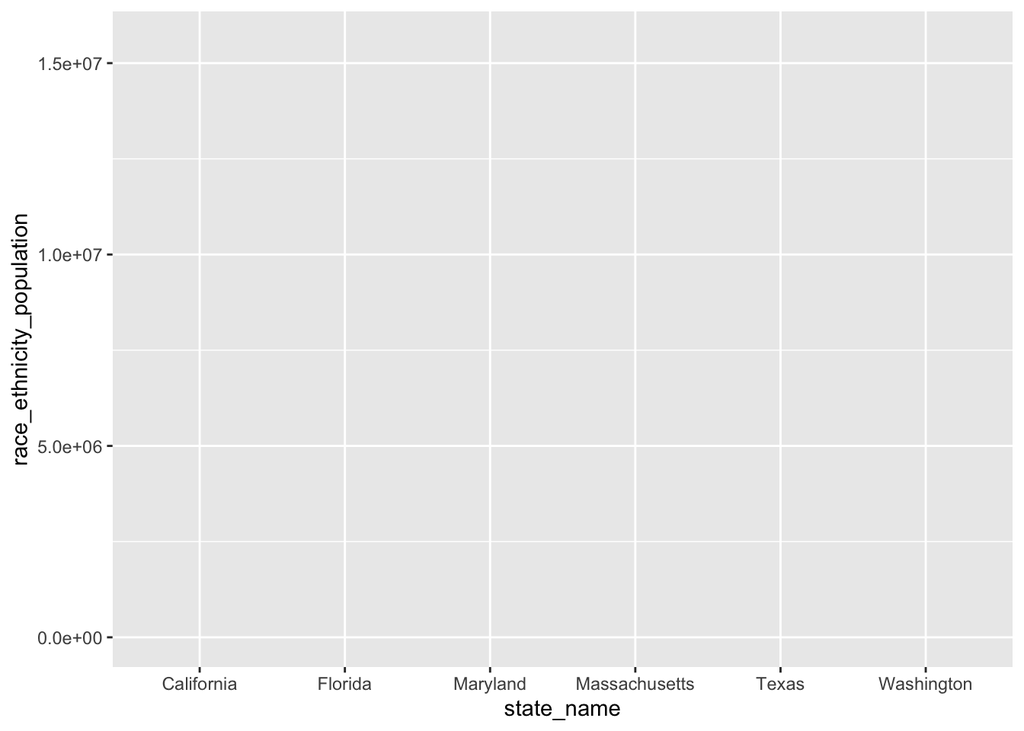

```r
p1 <- ggplot(
  selected_states,
  aes(
    x = state_name,
    y = race_ethnicity_population,
    fill = race_ethnicity
  )
)

p1
```

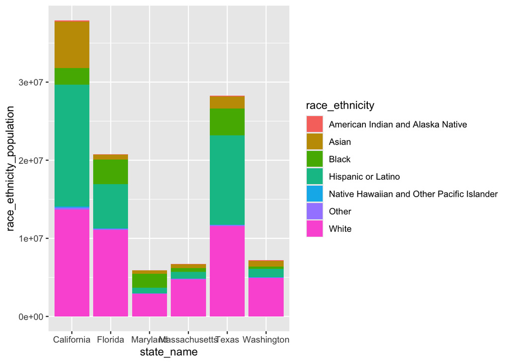

```r
p2 <- p1 +
  geom_col()

p2
```

Add labels and a theme.

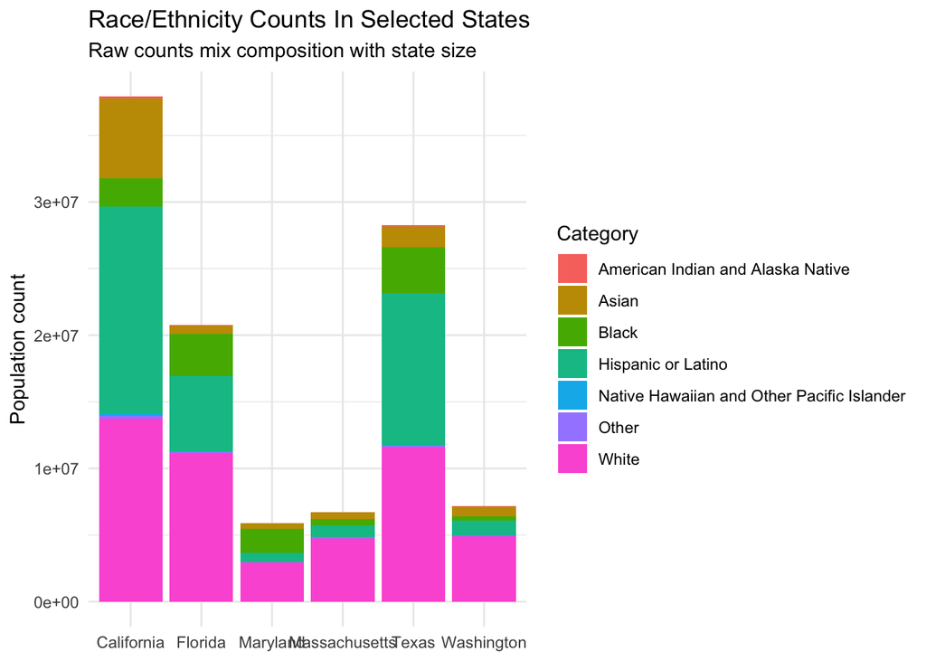

```r
p3 <- p2 +
  labs(
    title = "Race/Ethnicity Counts In Selected States",
    subtitle = "Raw counts mix composition with state size",
    x = NULL,
    y = "Population count",
    fill = "Category"
  ) +
  theme_minimal()

p3
```

Interpretation: California and Texas have larger bars partly because they have larger populations. That makes raw counts a poor choice if the question is composition.

# Proportions

The `share` variable gives each category’s share within the included race/ethnicity categories for that state.

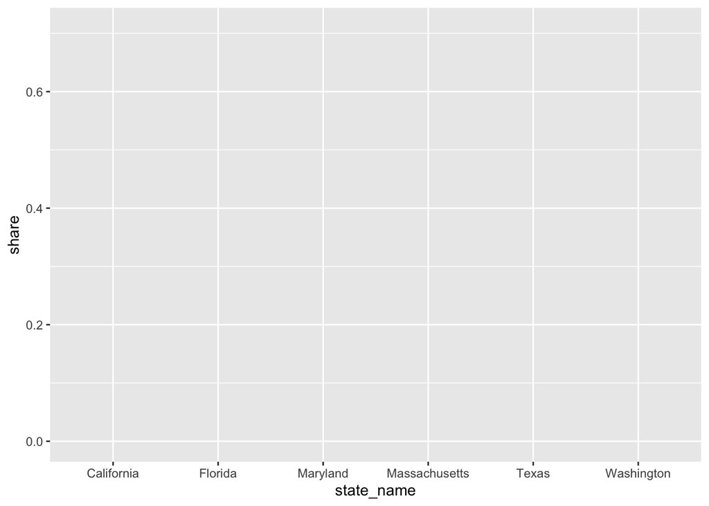

```r
p1 <- ggplot(
  selected_states,
  aes(
    x = state_name,
    y = share,
    fill = race_ethnicity
  )
)

p1
```

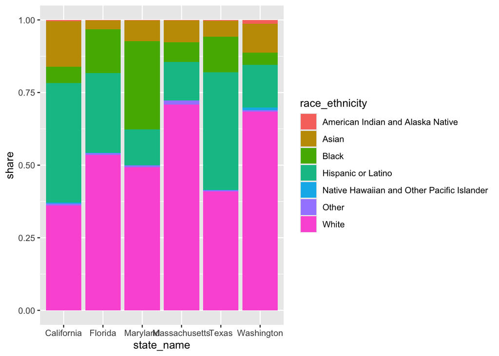

```r
p2 <- p1 +
  geom_col()

p2
```

Format the y-axis as percentages.

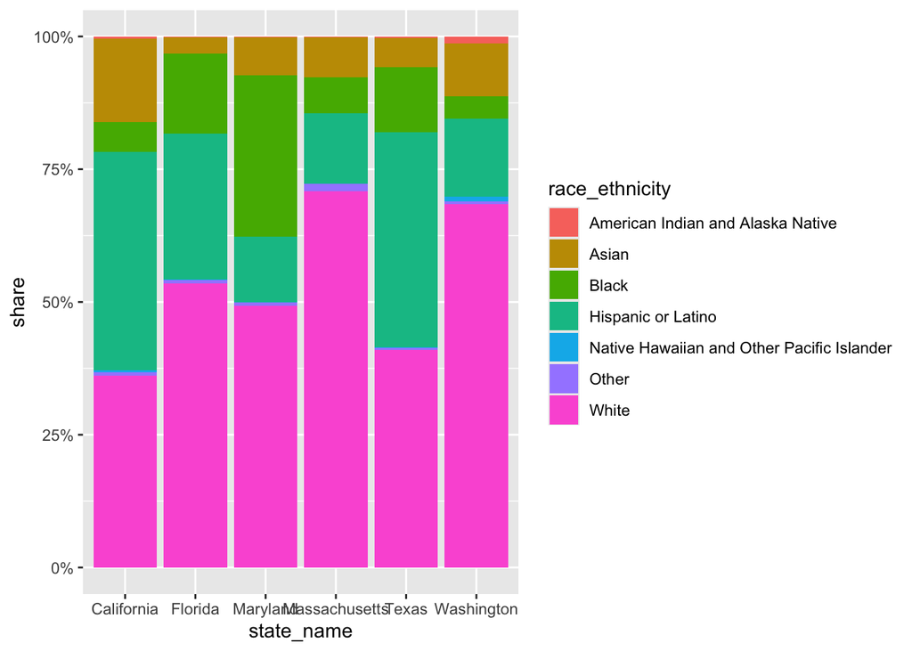

```r
p3 <- p2 +
  scale_y_continuous(
    labels = function(x) paste0(round(x * 100), "%")
  )

p3
```

Add labels and a theme.

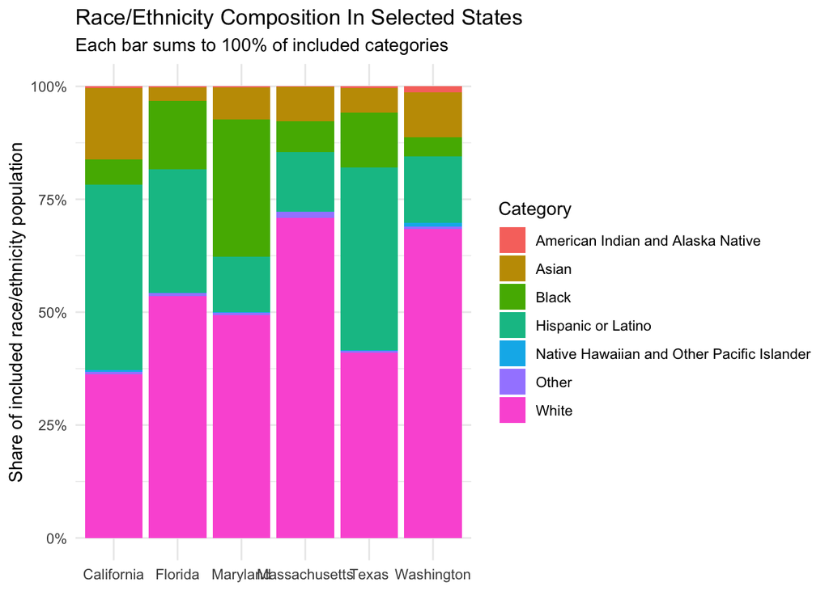

```r
p4 <- p3 +
  labs(
    title = "Race/Ethnicity Composition In Selected States",
    subtitle = "Each bar sums to 100% of included categories",
    x = NULL,
    y = "Share of included race/ethnicity population",
    fill = "Category"
  ) +
  theme_minimal()

p4
```

# Make One Comparison Easier

Stacked bars show overall composition, but they make it hard to compare categories that do not share a common baseline.

If the question is about one category, filter to that category.

```r
hispanic_share <- census |>
  filter(race_ethnicity == "Hispanic or Latino") |>
  mutate(state_name = reorder(state_name, share))

hispanic_share |>
  select(state_name, share) |>
  head()
```

```
# A tibble: 6 × 2
  state_name     share
  <fct>          <dbl>
1 Massachusetts 0.132
2 Hawaii        0.119
3 New Hampshire 0.0449
4 Rhode Island  0.174
5 Vermont       0.0253
6 Connecticut   0.180
```

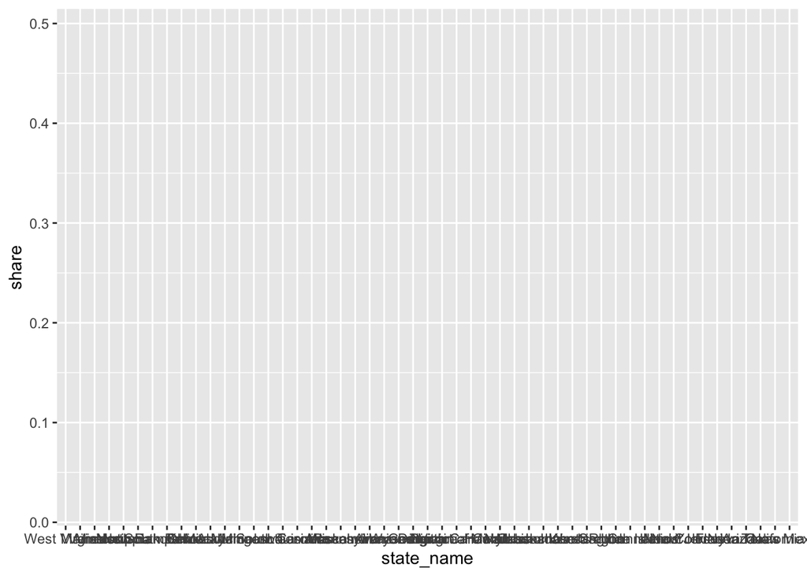

```r
p1 <- ggplot(
  hispanic_share,
  aes(x = state_name, y = share)
)

p1
```

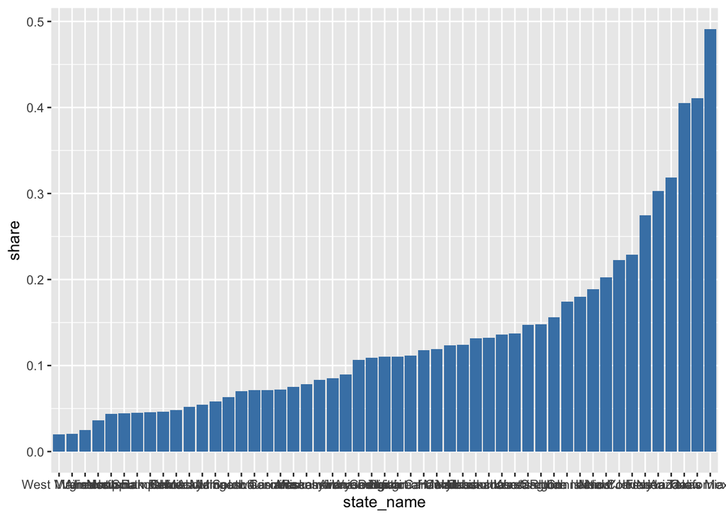

```r
p2 <- p1 +
  geom_col(fill = "steelblue")

p2
```

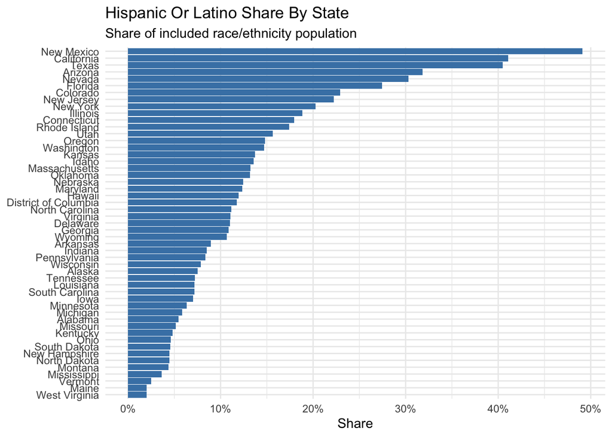

```r
p3 <- p2 +
  coord_flip() +
  scale_y_continuous(
    labels = function(x) paste0(round(x * 100), "%")
  ) +
  labs(
    title = "Hispanic Or Latino Share By State",
    subtitle = "Share of included race/ethnicity population",
    x = NULL,
    y = "Share"
  ) +
  theme_minimal()

p3
```

Interpretation: filtering to one category makes the cross-state comparison easier than reading that category out of every stacked bar.

# Takeaways

- Composition asks what a whole is made of.
- Raw counts and proportions answer different questions.
- Stacked bars are useful for showing a whole, but weak for comparing many individual segments.
- When the question is about one category, plot that category directly.